# bank_marketing_UCI

```python
import pandas as pd
import matplotlib.pyplot as plt
import seaborn as sns
import numpy as np
sns.set()

df = pd.read_csv("bankmarketing.csv")
```

```python
df.head()
```

|  | age | job | marital | education | default | housing | loan | contact | month | day_of_week | ... | campaign | pdays | previous | poutcome | emp.var.rate | cons.price.idx | cons.conf.idx | euribor3m | nr.employed | y |
| --- | --- | --- | --- | --- | --- | --- | --- | --- | --- | --- | --- | --- | --- | --- | --- | --- | --- | --- | --- | --- | --- |
| 0 | 56 | housemaid | married | basic.4y | no | no | no | telephone | may | mon | ... | 1 | 999 | 0 | nonexistent | 1.1 | 93.994 | -36.4 | 4.857 | 5191.0 | no |
| 1 | 57 | services | married | high.school | unknown | no | no | telephone | may | mon | ... | 1 | 999 | 0 | nonexistent | 1.1 | 93.994 | -36.4 | 4.857 | 5191.0 | no |
| 2 | 37 | services | married | high.school | no | yes | no | telephone | may | mon | ... | 1 | 999 | 0 | nonexistent | 1.1 | 93.994 | -36.4 | 4.857 | 5191.0 | no |
| 3 | 40 | admin. | married | basic.6y | no | no | no | telephone | may | mon | ... | 1 | 999 | 0 | nonexistent | 1.1 | 93.994 | -36.4 | 4.857 | 5191.0 | no |
| 4 | 56 | services | married | high.school | no | no | yes | telephone | may | mon | ... | 1 | 999 | 0 | nonexistent | 1.1 | 93.994 | -36.4 | 4.857 | 5191.0 | no |

5 rows × 21 columns

```python
df.shape
```

```
(41188, 21)
```

```python
df['y'].value_counts()/df.shape[0]
```

```
no     0.887346
yes    0.112654
Name: y, dtype: float64
```

Dataset was obtained from the UCI repo. The following is from its description:  
The data is related with direct marketing campaigns of a Portuguese banking institution. The marketing campaigns were based on phone calls. Often, more than one contact to the same client was required, in order to access if the product (bank term deposit) would be (or not) subscribed.  
The classification goal is to predict if the client will subscribe a term deposit (variable y).  
Note: we have imbalanced classes.

```python
num_cols = df.select_dtypes(include=np.number).columns.tolist()
cat_cols = list(set(df.columns.tolist())-set(num_cols))
```

```python
df[cat_cols].describe()
```

|  | poutcome | job | y | loan | default | housing | day_of_week | contact | education | marital | month |
| --- | --- | --- | --- | --- | --- | --- | --- | --- | --- | --- | --- |
| count | 41188 | 41188 | 41188 | 41188 | 41188 | 41188 | 41188 | 41188 | 41188 | 41188 | 41188 |
| unique | 3 | 12 | 2 | 3 | 3 | 3 | 5 | 2 | 8 | 4 | 10 |
| top | nonexistent | admin. | no | no | no | yes | thu | cellular | university.degree | married | may |
| freq | 35563 | 10422 | 36548 | 33950 | 32588 | 21576 | 8623 | 26144 | 12168 | 24928 | 13769 |

# Visualizing the Data

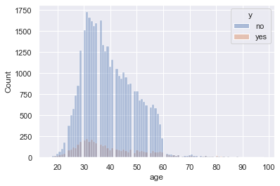

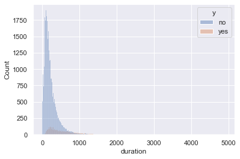

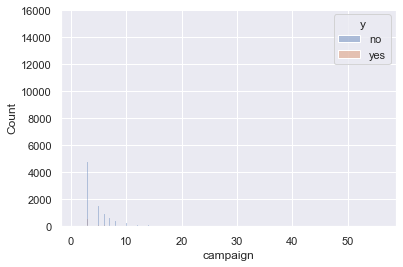

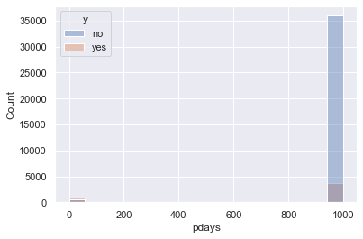

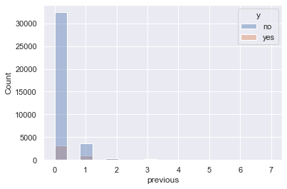

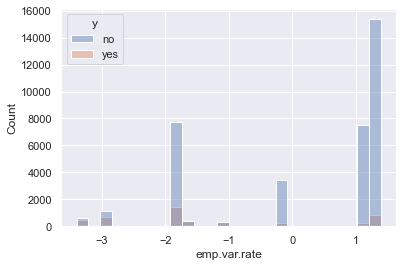

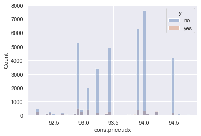

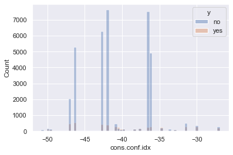

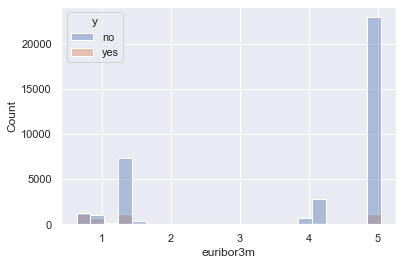

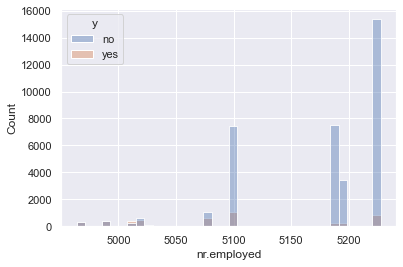

```python
for i in num_cols:
    sns.histplot(data=df,x=i,hue='y',alpha=0.4)
    plt.xlabel(i)

    plt.show()
```

'previous' is highly skewed, with the overwhelming majority at 0.

```python
df['previous'].value_counts()
```

```
0    35563
1     4561
2      754
3      216
4       70
5       18
6        5
7        1
Name: previous, dtype: int64
```

'campaign' - we see a similar situation here. The majority of values are < 10. There is a long, thing tail > 10.

```python
df['campaign'].loc[df['campaign']>10].value_counts()
```

```
11    177
12    125
13     92
14     69
17     58
16     51
15     51
18     33
20     30
19     26
21     24
22     17
23     16
24     15
27     11
```

[output cut: 18 more lines]

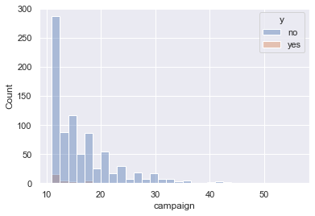

```python
sns.histplot(data=df.loc[df['campaign']>10],x='campaign',hue='y',alpha=0.4,bins=30)
plt.show()
```

'pdays' - number of days that passed by after the client was last contacted from a previous campaign 999 means client was not previously contacted. Lets set it to -1 - this makes the distribution not so wide spread. -1 also happens to be the overwhelmingly majority value.

```
-1     39673
 3       439
 6       412
 4       118
 9        64
 2        61
 7        60
 12       58
 10       52
 5        46
 13       36
 11       28
 1        26
 15       24
 14       20
 8        18
 0        15
 16       11
 17        8
 18        7
 22        3
 19        3
 21        2
 25        1
 26        1
 27        1
 20        1
Name: pdays, dtype: int64
```

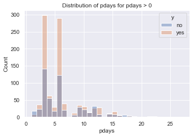

```python
df['pdays'] = df['pdays'].replace(to_replace=999,value=-1)
print(df['pdays'].value_counts())
sns.histplot(data=df.loc[df['pdays']>0,['pdays','y']],x='pdays',hue='y',alpha=0.4,bins=30)
plt.title('Distribution of pdays for pdays > 0')
plt.show()
```

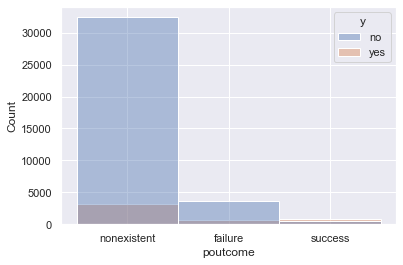

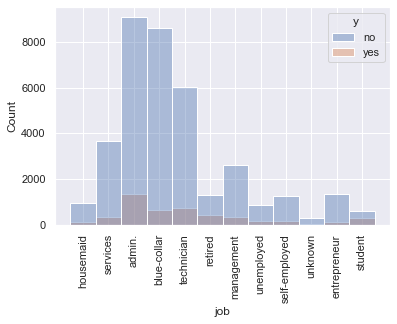

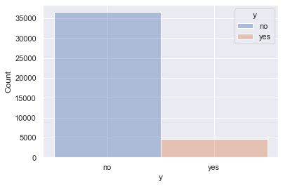

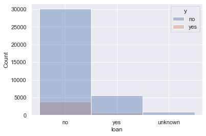

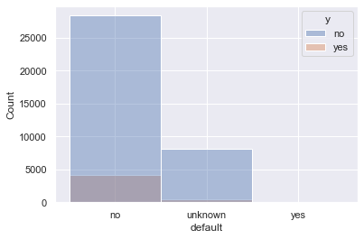

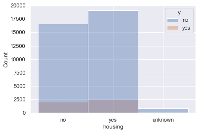

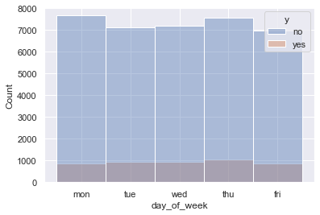

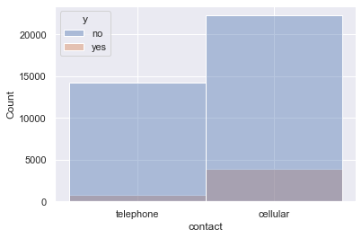

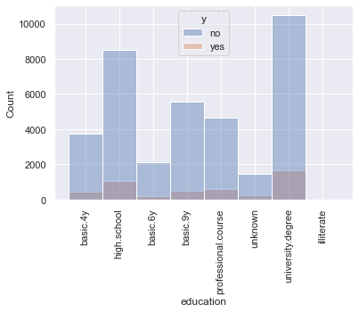

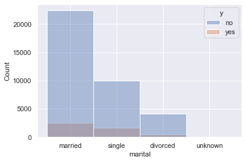

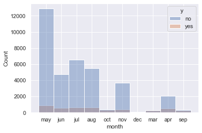

```python
for i in cat_cols:
    sns.histplot(data=df,x=i,hue='y',alpha=0.4)
    plt.xlabel(i)
    if(i in ['education','job']):
        plt.xticks(rotation=90)
    plt.show()
```

```python
job_values = df['job'].value_counts().index.tolist()
print("Target distributions for each unique value in 'job'")
for i in job_values:
    print("\nTarget distribution for {}".format(i))
    idx = df['job'].loc[df['job']==i].index
    print(df['y'].loc[idx].value_counts()/df['y'].loc[idx].shape[0])
```

```
Target distributions for each unique value in 'job'

Target distribution for admin.
no     0.870274
yes    0.129726
Name: y, dtype: float64

Target distribution for blue-collar
no     0.931057
yes    0.068943
Name: y, dtype: float64

Target distribution for technician
no     0.89174
yes    0.10826
Name: y, dtype: float64

Target distribution for services
no     0.918619
yes    0.081381
Name: y, dtype: float64

Target distribution for management
no     0.887825
yes    0.112175
Name: y, dtype: float64

Target distribution for retired
no     0.747674
yes    0.252326
Name: y, dtype: float64

Target distribution for entrepreneur
no     0.914835
yes    0.085165
Name: y, dtype: float64

Target distribution for self-employed
no     0.895144
yes    0.104856
Name: y, dtype: float64

Target distribution for housemaid
no     0.9
yes    0.1
Name: y, dtype: float64

Target distribution for unemployed
no     0.857988
yes    0.142012
Name: y, dtype: float64

Target distribution for student
no     0.685714
yes    0.314286
Name: y, dtype: float64

Target distribution for unknown
no     0.887879
yes    0.112121
Name: y, dtype: float64
```

student and retired are the clear outliers, with the fraction of 1s at 0.31 and 0.25 respectively. For all the remaining, the fraction of 1s is around 0.1. We'll turn 'job' into a binary variable: 'student' or 'retired' (1) versus others (0)

```python
marital_values = df['marital'].value_counts().index.tolist()
print("Target distributions for each unique value in 'marital'")
for i in marital_values:
    print("\nTarget distribution for {}".format(i))
    idx = df['marital'].loc[df['marital']==i].index
    print(df['y'].loc[idx].value_counts()/df['y'].loc[idx].shape[0])
```

```
Target distributions for each unique value in 'marital'

Target distribution for married
no     0.898427
yes    0.101573
Name: y, dtype: float64

Target distribution for single
no     0.859959
yes    0.140041
Name: y, dtype: float64

Target distribution for divorced
no     0.896791
yes    0.103209
Name: y, dtype: float64

Target distribution for unknown
no     0.85
yes    0.15
Name: y, dtype: float64
```

There are no stark differences in dsitributions of 0s and 1s here. The only thing which I can see is 'married' and 'divorced' have fraction of 1s at 0.1, and 'single' and 'unknown' have it at 0.14 and 0.15 respectively. We can 'binarize' this as 'married' and 'divorced' being 1s and 'single' and 'unknown' being 0s.

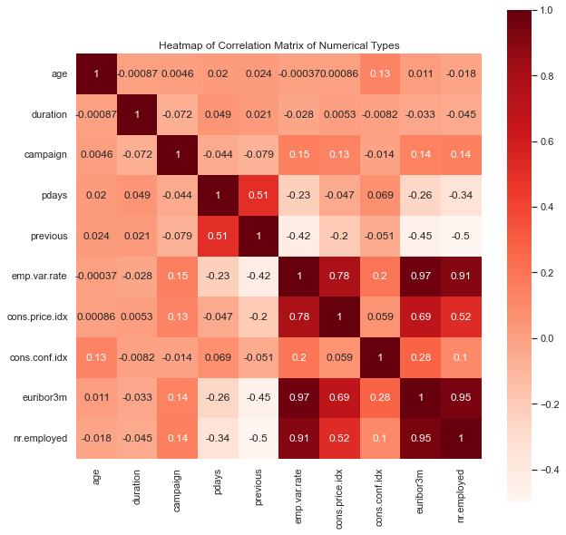

```python
corr = df[num_cols].corr()

fig,ax = plt.subplots(figsize=(10,10))
sns.heatmap(corr,square=True,annot=True,cbar=True,cmap='Reds',ax=ax)
plt.title('Heatmap of Correlation Matrix of Numerical Types')
plt.show()
```

# Model Fitting

```python
'''
'month' - missing months in dataset. encode them as jan = 1, feb = 2, etc
'contact' - telephone as 0, cellular as 1
'day_of_week' - encode mon as 1, tue as 2, etc
'education' - 8 uniques - basic.4y,high.school,basic.6y,basic.9y,professional.couse, unknown, university.degree, illiterate
encoding as:
'unknown':0,'illiterate':1,'basic.4y':2,'basic.6y':3,'basic.9y':4,
                                           'high.school':5,'professional.course':6,'university.degree':7
'marital' - encoding as 'married':1,'divorced':1,'single':0,'unknown':0

'job' - encoding as 'retired','student': 1, others: 0
'''

def manual_encoders(df_in):
    month_enc = {'jan':1,'feb':2,'mar':3,'apr':4,'may':5,'jun':6,
                                   'jul':7,'aug':8,'sep':9,'oct':10,'nov':11,'dec':12}
    day_enc = {'mon':1,'tue':2,'wed':3,'thu':4,'fri':5}
    contact_enc = {'telephone':0,'cellular':1}
    education_enc = {'unknown':0,'illiterate':1,'basic.4y':2,'basic.6y':3,'basic.9y':4,
                                           'high.school':5,'professional.course':6,'university.degree':7}
    poutcome_enc = {'success':0.0,'failure':1.0,'nonexistent':0.5}

    df_in['month'] = df_in['month'].replace(month_enc)
    df_in['day_of_week'] = df_in['day_of_week'].replace(day_enc)
    df_in['contact'] = df_in['contact'].replace(contact_enc)
    df_in['education'] = df_in['education'].replace(education_enc)
    df_in['poutcome'] = df_in['poutcome'].replace(poutcome_enc)

    lhd_enc = {'no':0.0,'yes':1.0,'unknown':0.5} #encoder for loan, housing and default
    lhd_col = list(['loan','housing','default'])
    df_in[lhd_col] = df_in[lhd_col].replace(lhd_enc)

    marital_enc = {'married':1,'divorced':1,'single':0,'unknown':0}
    df_in['marital'] = df_in['marital'].replace(marital_enc)

    job_enc = {'admin.':0,'blue-collar':0,'technician':0,'services':0,'management':0,'retired':1,'entrepreneur':0,
           'self-employed':0,'housemaid':0,'unemployed':0,'student':1,'unknown':0}
    df_in['job'] = df_in['job'].replace(job_enc)

    y_enc = {'no':0,'yes':1}
    df_in['y'] = df_in['y'].replace(y_enc)

    return(df_in)

df = manual_encoders(df)
```

```python
from sklearn.model_selection import train_test_split

trainX, testX, y_train, y_test = train_test_split(df.drop('y',axis=1),df['y'],test_size = 0.2,random_state=2)

print('Training Set:')
print(y_train.value_counts()/y_train.shape[0])
print('\nTest Set:')
print(y_test.value_counts()/y_test.shape[0])
```

```
Training Set:
0    0.887102
1    0.112898
Name: y, dtype: float64

Test Set:
0    0.888322
1    0.111678
Name: y, dtype: float64
```

```python
from sklearn.preprocessing import MinMaxScaler

scaler = MinMaxScaler()
scaler.fit(trainX)

X_train = scaler.transform(trainX)
X_test = scaler.transform(testX)
```

```python
from sklearn.metrics import recall_score, accuracy_score
from sklearn.svm import SVC
from sklearn.naive_bayes import GaussianNB
from sklearn.linear_model import LogisticRegression, SGDClassifier
from sklearn.tree import DecisionTreeClassifier
from xgboost import XGBClassifier
from lightgbm import LGBMClassifier
from catboost import CatBoostClassifier
```

```python
classifiers = [SVC(kernel='rbf'),
               GaussianNB(),
               SGDClassifier(),
               LogisticRegression(),
               DecisionTreeClassifier(),
               XGBClassifier(use_label_encoder=False),
               LGBMClassifier(),
               CatBoostClassifier(verbose=False)]

scores_df = pd.DataFrame(columns=['Classifier','TestRecall','TestAccuracy','TrainRecall','TrainAccuracy'])

for i in classifiers:
    i.fit(X_train,y_train)
    y_pred_test = i.predict(X_test)
    y_pred_train = i.predict(X_train)
    scores_df.loc[len(scores_df.index)] = [i.__class__.__name__,recall_score(y_test,y_pred_test),
                                           accuracy_score(y_test,y_pred_test),
                                           recall_score(y_train,y_pred_train),
                                           accuracy_score(y_train,y_pred_train)]
```

[output not shown]

```python
scores_df.sort_values(by='TestRecall')
```

|  | Classifier | TestRecall | TestAccuracy | TrainRecall | TrainAccuracy |
| --- | --- | --- | --- | --- | --- |
| 2 | SGDClassifier | 0.218478 | 0.904346 | 0.234140 | 0.902822 |
| 0 | SVC | 0.251087 | 0.906045 | 0.282258 | 0.907102 |
| 3 | LogisticRegression | 0.356522 | 0.910294 | 0.377151 | 0.909439 |
| 4 | DecisionTreeClassifier | 0.526087 | 0.889900 | 1.000000 | 1.000000 |
| 7 | CatBoostClassifier | 0.526087 | 0.914664 | 0.695430 | 0.951108 |
| 5 | XGBClassifier | 0.540217 | 0.916120 | 0.745161 | 0.957117 |
| 6 | LGBMClassifier | 0.563043 | 0.917334 | 0.664785 | 0.938695 |
| 1 | GaussianNB | 0.573913 | 0.845958 | 0.600000 | 0.841487 |

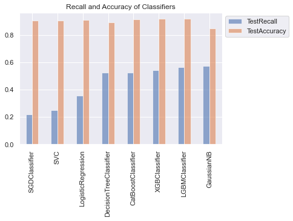

```python
scores_df.sort_values(by='TestRecall').plot.bar(x='Classifier',y=['TestRecall','TestAccuracy'],alpha=0.6)
plt.legend(bbox_to_anchor=(1,1))
plt.title('Recall and Accuracy of Classifiers')
plt.xlabel(None)
plt.show()
```

Model performance isn't stellar wrt to recall score, but it isn't abysmal either. Given the low fraction of 1s (~11%), I think performance of our workhorse classifiers (catboost, xgboost and lgbm) is pretty good. Let's use our old trick - upsample the minority class.

# Up-sampling the Minority class

```python
traindf = pd.concat([trainX,pd.DataFrame(y_train)],axis=1)

n0, n1 = traindf['y'].value_counts()

class0 = traindf[traindf['y'] == 0]
class1 = traindf[traindf['y'] == 1]
```

```python
print("Before Resampling")
print("Fraction of class 1: {}".format(n1/(n0+n1)))

#we'll boost fraction of class 1 from ~11% to ~40%.
#taking 6*n1 samples gives us ~44%

class1over = class1.sample(6*n1,replace=True)
overdf = pd.concat([class0,class1over],axis=0).sample(frac=1)

print("After Resampling")
print("Fraction of class 0: {}".format(overdf['y'].value_counts()[1]/overdf.shape[0]))
```

```
Before Resampling
Fraction of class 1: 0.11289833080424887
After Resampling
Fraction of class 0: 0.4329776915615907
```

```python
trainXover, y_train = overdf.drop('y',axis=1),overdf['y']
```

```python
X_train = scaler.transform(trainXover)
```

```python
#fitting our classifiers again
classifiers = [SVC(kernel='rbf'),
               GaussianNB(),
               SGDClassifier(),
               LogisticRegression(),
               DecisionTreeClassifier(),
               XGBClassifier(use_label_encoder=False),
               LGBMClassifier(),
               CatBoostClassifier(verbose=False)]

scores_df_over = pd.DataFrame(columns=['Classifier','TestRecall','TestAccuracy','TrainRecall','TrainAccuracy'])

for i in classifiers:
    i.fit(X_train,y_train)
    y_pred_test = i.predict(X_test)
    y_pred_train = i.predict(X_train)
    scores_df_over.loc[len(scores_df_over.index)] = [i.__class__.__name__,recall_score(y_test,y_pred_test),
                                           accuracy_score(y_test,y_pred_test),
                                           recall_score(y_train,y_pred_train),
                                           accuracy_score(y_train,y_pred_train)]
```

[output not shown]

```python
scores_df_over.sort_values(by='TestRecall')
```

|  | Classifier | TestRecall | TestAccuracy | TrainRecall | TrainAccuracy |
| --- | --- | --- | --- | --- | --- |
| 4 | DecisionTreeClassifier | 0.482609 | 0.891357 | 1.000000 | 1.000000 |
| 1 | GaussianNB | 0.694565 | 0.825929 | 0.705063 | 0.779554 |
| 5 | XGBClassifier | 0.818478 | 0.893299 | 0.980108 | 0.947992 |
| 3 | LogisticRegression | 0.821739 | 0.875091 | 0.819355 | 0.852396 |
| 7 | CatBoostClassifier | 0.855435 | 0.891964 | 0.974328 | 0.940019 |
| 0 | SVC | 0.873913 | 0.866230 | 0.897401 | 0.878914 |
| 2 | SGDClassifier | 0.878261 | 0.853848 | 0.871729 | 0.857730 |
| 6 | LGBMClassifier | 0.891304 | 0.880918 | 0.965412 | 0.921707 |

Performance is definitely much better now, and more importantly, there is very little overfitting for most models (except for DecisionTree, of course, always). Even simple LogisticRegression is performance good across the board, with similar scores in all columns (train, test accuracy and recall). SVC has around 87% accuracy and recall across the board on train and test sets.  
NOTE: this is performance before hyperparameter tuning.

#### Feature Importance

Lets look at feature importance from out best model: LGBM

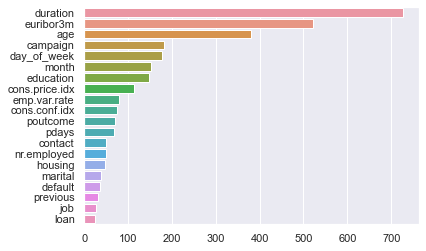

```python
feat_imp = classifiers[6].feature_importances_
feat_imp_arg, feat_imp = np.flip(np.argsort(feat_imp)), np.flip(np.sort(feat_imp))
feat_imp_names = trainX.columns[feat_imp_arg].tolist()

sns.barplot(x=feat_imp,y=feat_imp_names)
plt.show()
```

From the documentation on the dataset:  
duration: last contact duration, in seconds (numeric) campaign: number of contacts performed during this campaign and for this client (numeric, includes last contact) euribor3m - not mentioned in the documentation, but I remember reading somewhere this is some economic index. age - self-explanatory day_of_week - surprisingly, its in top 5.